# RStudio for beginners

2023-01-30

## Rでデータ解析を始めよう

## 1. はじめに

### 今日の目標

- RStudioに親しみを感じる
- RStudioの解析環境の基礎を知る
- データの読み込み方を知る
- 読み込んだデータを加工する
- データを可視化する
- 簡単な統計解析を関数で実行する

### 資料のURL

- https://ytake2.github.io/R-for-beginners/RStudio4beginners.html

### 講師とRの馴れ初め

- R歴13年くらい (臨床心理士歴13年くらい)
  - Rを遠目でみる時期: M2でRの存在を知る
  - Rと少し接近: D1の研究室移動でR入門
  - R束縛期: D2でSPSSとAMOSをアンインストール
  - R依存期: D3〜社会人3年目、なんでもRでやりたい、Rを触ってないと体調が崩れる
    - [ホームページ](https://ytake2.github.io/Rsite/_site/index.html)も[ブログ](https://ytake2.github.io/takeblog/2019/12/21/crm-stan-trialr/)も[スライド](https://ytake2.github.io/DARM20160327/DARMlong.html#/2/4)もRで作って、[論文](https://www.jstage.jst.go.jp/article/jjbct/advpub/0/advpub_21-024/_pdf/-char/ja)もRで書く
    - [RStudioでできるあんなことやとこんなこと](https://ytake2.github.io/DARM20160327/DARMlong.html#/2/4)
  - Rまんねり期: そろそろpyhtonとか他の言語もやりたい
  - Rやっぱりお前しかいない期: 他言語にふれRの良さを再認識 <- いまここ

### 下準備

- Rでデータ解析をする環境は無料で構築可能
- R / RStudioのインストール
  - [Rのインストール](https://cran.r-project.org/)
    - mac / m1 mac
    - windows
  - [RStudioのインストール](https://posit.co/downloads/)
  - [Posit Cloudの使用](https://posit.cloud/plans/free)
    - クラウドを介してブラウザでRStudioを使える
    - マシンの環境に依存せずにつかる
    - ただしフリープランは使用できる容量に制限あり
    - googleやgithubのアカウントでソーシャルログイン可能
    - 今日の最終的な環境は下記のURLから移植できます
      - https://posit.cloud/content/5316019
- RStudioの環境設定
  - 4つのmain pane
    - Source
    - Console
    - Environment
    - plot / files / package / help
  - 自分好みの配置、配色 (global option)
  - [RStudio の環境設定に関するチートシート](https://posit.co/wp-content/uploads/2022/10/rstudio-ide-1.pdf)

## 2. データの読み込み

- `Environment` -> `Import dataset`
  - 多様な形式のファイルを読み込み可能
  - テキストファイル (.txt, .csv)やエクセル(.xlsx)はもちろん
  - SPSS, SAS, Stataで保存したデータも読み込み可能
- CSVファイルの読み込み
  - サンプルデータ: dataset-72268.csv
  - うつ治療のウェブプログラムBtheBの効果検証データ
    - データの読み込み
      - `Environment` -> `Import dataset` -> `from text (readr)`

```r
library(readr)
data <- read_csv("data/dataset-72268.csv")
#View(data)
```

- データの中をみてみよう
  - `View(data)` ローデータを確認
  - `Environment pane` でオブジェクトの構造把握
  - `str(data)` でオブジェクトの構造把握

| 変数名 | データ内容 | 変数型 |
| --- | --- | --- |
| drug | 抗うつ薬処方の有無 | chr |
| length | うつの現病歴の期間 m =month | chr |
| treatment | 治療群 (BtheB vs TAU(通常治療)) | chr |
| bdi.pre | 治療前の抑うつスコア (BDIで測定） | dbl |
| bdi.2m | 2ヶ月後の抑うつスコア (BDIで測定) | dbl |
| bdi.4m | 4ヶ月後の抑うつスコア (BDIで測定) | dbl |
| bdi.6m | 6ヶ月後の抑うつスコア (BDIで測定) | dbl |
| bdi.8m | 8ヶ月後の抑うつスコア (BDIで測定) | dbl |

```r
str(data)
```

```
## spc_tbl_ [100 × 8] (S3: spec_tbl_df/tbl_df/tbl/data.frame)
##  $ drug     : chr [1:100] "No" "Yes" "Yes" "No" ...
##  $ length   : chr [1:100] ">6m" ">6m" "<6m" ">6m" ...
##  $ treatment: chr [1:100] "TAU" "BtheB" "TAU" "BtheB" ...
##  $ bdi.pre  : num [1:100] 29 32 25 21 26 7 17 20 18 20 ...
##  $ bdi.2m   : num [1:100] 2 16 20 17 23 0 7 20 13 5 ...
##  $ bdi.4m   : num [1:100] 2 24 NA 16 NA 0 7 21 14 5 ...
##  $ bdi.6m   : num [1:100] NA 17 NA 10 NA 0 3 19 20 8 ...
##  $ bdi.8m   : num [1:100] NA 20 NA 9 NA 0 7 13 11 12 ...
##  - attr(*, "spec")=
##   .. cols(
##   ..   drug = col_character(),
##   ..   length = col_character(),
##   ..   treatment = col_character(),
##   ..   bdi.pre = col_double(),
##   ..   bdi.2m = col_double(),
##   ..   bdi.4m = col_double(),
##   ..   bdi.6m = col_double(),
##   ..   bdi.8m = col_double()
##   .. )
##  - attr(*, "problems")=<externalptr>
```

### データの型

| データ型 | 説明 | 例 |
| --- | --- | --- |
| integer (numeric) | 整数型 | 1,-1,203 |
| double (numeric) | 実数型 | 3.1415,-0.001 |
| character | 文字型 | “A”,“13” |
| logical | 論理型 | TRUE, FALSE |
| factor | カテゴリカル変数 |  |

### [データの読み込みに関するreadrなどのチートシート](https://posit.co/wp-content/uploads/2022/10/data-import.pd)

## 3. データを加工

- `tidyverse` パッケージはデータ整形に便利な複数のパッケージを統合
- Rで解析する際にはとりあえず読み込んどく

### パッケージの読みこみ

```r
library(tidyverse)
```

#### データ作成

```r
item1<-sample(5,100,T)
item2<-sample(5,100,T)
item3<-sample(5,100,T)

sample.data<-data.frame(item1,item2,item3)

as_tibble(sample.data)
```

```
## # A tibble: 100 × 3
##    item1 item2 item3
##    <int> <int> <int>
##  1     5     5     5
##  2     3     4     5
##  3     4     2     5
##  4     5     3     4
##  5     5     5     3
##  6     1     1     4
##  7     3     5     1
##  8     2     3     3
##  9     1     1     3
## 10     4     3     2
## # … with 90 more rows
```

### Rの四則演算, 論理記号

[output not shown]

### 逆転項目を反転させてデータに追加

- `|>` or `%>%` はデータを次の関数に引きわたす呪文
- `mutate(追加する変数名 = 関数）` データフフレームに処理をした変数列を追加

```r
sample.data<-sample.data |>
  mutate(item2_r = 6-item2,
         item3_r = 6-item3)
```

### 複数の項目に同じ処理を適用させる

- `mutate_at(vars(複数の列名), 関数)`
- `vars`で指定した変数全てに同じ関数を適用する

```r
sample.data<-sample.data |>
  mutate_at(vars(c(item1,item2,item3)),
            ~6-.)
```

### 複数の変数を抽出するのに便利な関数

- `starts_with("文字列")` で、指定した文字列で始まる変数名の列を全てピックアップ
- `ends_with("文字列")`で、指定した文字列で終わる変数名の列を全てピックアップ
- `contains("文字列")`で、指定した文字列を含む変数名の列を全てピックアップ
- `num_range("文字列",数値範囲)`で、指定した文字列に通し番号がついてる（例えばitem1,item2,…,item10)場合に、指定した数値範囲の変数名の列を全てピックアップ
  - 以下はすべて、先のコードと同様の結果を返す

```r
sample.data<-sample.data |>
  mutate_at(vars(starts_with("item")),
            ~6-.)

sample.data<-sample.data |>
  mutate_at(vars(contains("item")),
            ~6-.)

sample.data<-sample.data |>
  mutate_at(vars(num_range("item",1:3)),
            ~6-.)
```

### 合計点をデータに追加

```r
sample.data<-sample.data |>
  mutate(total=item1+item2+item3)
```

### 得点を中心化してデータに追加

- 中心化得点 = 素点 - 平均

```r
sample.data<-sample.data |>
  mutate(total_centered=total-mean(total))
```

### 得点を標準化してデータに追加

- 標準得点 = (素点 - 平均) / 標準偏差

```r
sample.data<-sample.data |>
  mutate(total_zscore=(total-mean(total))/sd(total))
```

### これまでの処理をつなげて書いてOK

```r
sample.data<-sample.data |>
  mutate(item2_r=6-item2,
         item3_r=6-item3,
         total=item1+item2+item3,
         total_centered=total-mean(total),
         total_zscore=(total-mean(total))/sd(total))
```

### 交互作用項を追加

- 中心化変数を二つ作成、それらをかけあわせる

```r
sample.data<-sample.data |>
  mutate(item2_c = item2-mean(item2),
         item3_c = item3-mean(item3),
         interaction_2_3=item2_c*item3_c)
```

### 文字データを数値に置き換える

```r
sample.data$ABC<-sample(c("A","B","C"),100,T)

sample.data<-sample.data |>
    mutate(ABC2num=as.numeric(as.factor(ABC)))
```

### 数値データを文字に置き換える

```r
sample.data<-sample.data |>
    mutate(
      ABC2num2ABC=recode(
        as.factor(ABC2num),
        '1' = 'A',
        '2' = 'B',
        '3' = 'C'))

sample.data<-sample.data |>
  mutate(ABC2num2ABC=factor(ABC2num,
                    levels=c("1", "2","3"),
                labels=LETTERS[1:3])
  )
```

### データフレームをエクスポートする

- 多様な形式で可能
- `write_csv(データフレーム, "任意のファイル名.csv")` でcsvファイルとしてエクスポート

```r
write_csv(sample.data, "data/sample.data.csv")
```

### データ加工に関するtidyr/dplyrチートシート

- [Data tidying with tidyr cheasheet](https://posit.co/wp-content/uploads/2022/10/tidyr.pdf)
- [Datatransformation with dplyr](https://posit.co/wp-content/uploads/2022/10/data-transformation-1.pdf)

## 4. データをプロットしてみよう

- `ggplot2` パッケージを使用を推奨
  - `tidyverse` を読み込んだ時に含まれている
  - BtheB データを色々とプロットして眺めてみる

### 治療前の抑うつ得点の群間差をみたい

- bdi.pre :治療前得点
- treatment: 群 (BtheB vs TAU)
- ggplot(data=使用するデータフレーム): 使用するデータフレームを指定

### 箱ひげ図: 1要因 (2群)

- geom_boxplot(aes(x=群の変数名, y=比較したい得点の変数名）

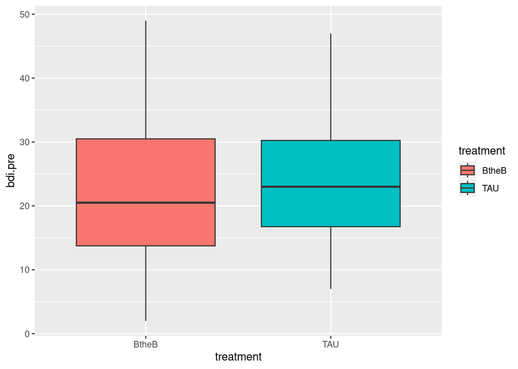

```r
ggplot(data=data)+
  geom_boxplot(aes(x=treatment,y=bdi.pre,fill=treatment))
```

### バイオリンプロット : 1要因 (2群)

- geom_violine(aes(x=群の変数名, y=比較したい得点の変数名）

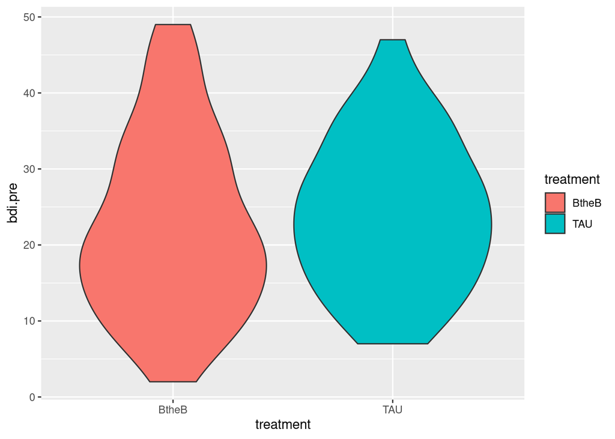

```r
ggplot(data=data)+
  geom_violin(aes(x=treatment,y=bdi.pre,fill=treatment))
```

### バイオリンプロット+箱ひげ図 : 1要因 (2群)

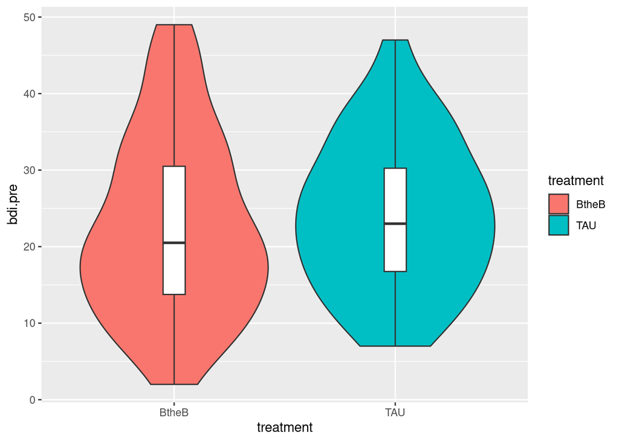

```r
ggplot(data=data,aes(x=treatment,y=bdi.pre,fill=treatment))+
  geom_violin()+
   geom_boxplot(width=.1,fill="white")
```

### 論文っぽく加工

- `xlab` `ylab` でx軸とy軸のラベルを変更
- `guides(fill=none)` で凡例を削除
- `scale_fill_manual(values = c("black","gray"))` で塗りつぶしの色を指定

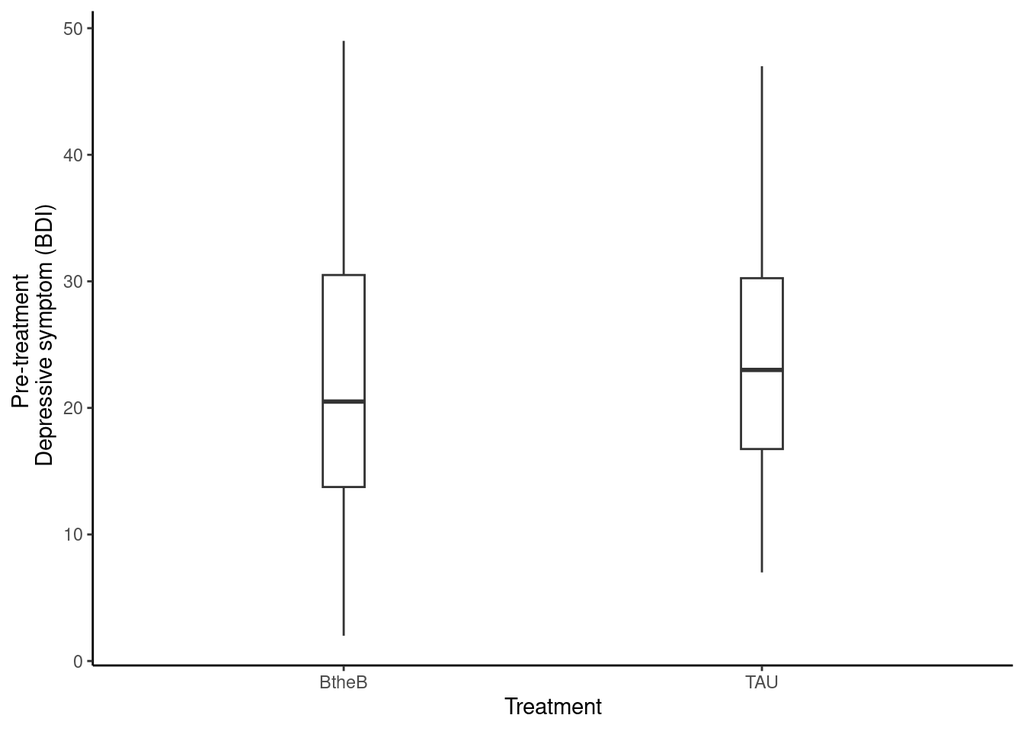

```r
ggplot(data=data,aes(x=treatment,y=bdi.pre,fill=treatment))+
   geom_boxplot(width=.1,fill="white")+
  xlab("Treatment")+ylab("Pre-treatment \n Depressive symptom (BDI)")+theme_classic() + guides(fill="none")+scale_fill_manual(values = c("black","gray"))
```

- もっと頑張るとこんな図を書いて論文にのせれます
  - [例1](https://www.researchgate.net/profile/Masato-Usuki/publication/301311934/figure/fig1/AS:360150859829251@1462878064104/ndividual-and-averaged-growth-trajectories-for-SIGH-A-SIGH-A-Structured-Interview_W640.jpg), [例2](https://ars.els-cdn.com/content/image/1-s2.0-S221242091930682X-gr1.jpg), [例3](https://www.frontiersin.org/files/Articles/276314/fpsyt-08-00143-HTML/image_m/fpsyt-08-00143-g002.jpg), [例4](https://econtent.hogrefe.com/cms/10.1027/0227-5910/a000679/asset/images/medium/0227-5910_a000679_fig2a.gif), [例5](https://econtent.hogrefe.com/cms/10.1027/0227-5910/a000679/asset/images/medium/0227-5910_a000679_fig1a.gif)

### 箱ヒゲ図: 2要因 (2群(群) * 2群(処方))

- 薬物療法の処方の有無で治療前の抑うつ得点の群間差が異なるか

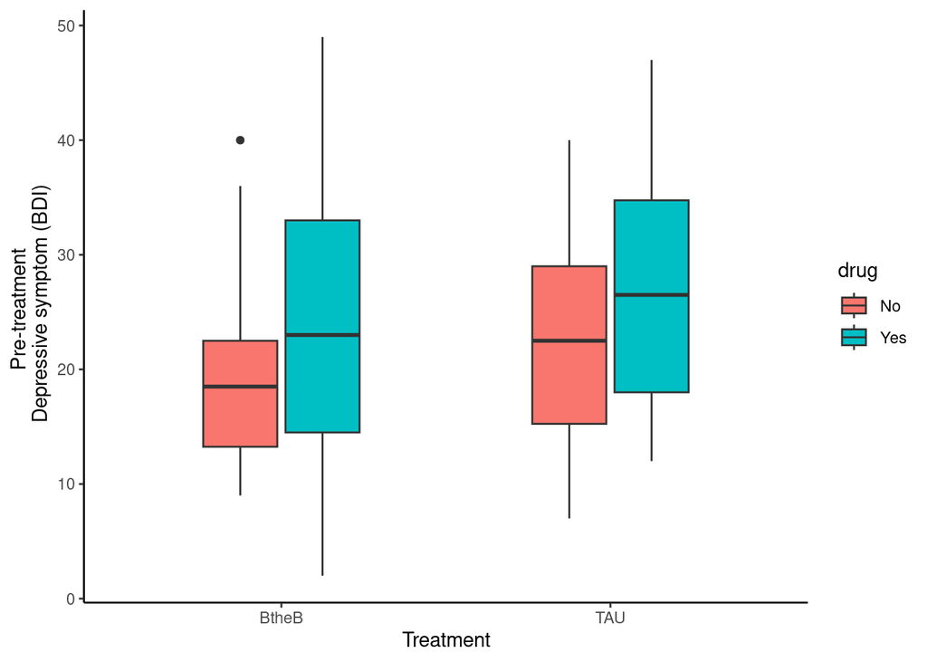

```r
ggplot(data=data,aes(x=treatment,y=bdi.pre,fill=drug))+geom_boxplot(width=.5)+   xlab("Treatment")+ylab("Pre-treatment \n Depressive symptom (BDI)")+theme_classic()
```

### 箱ヒゲ図: 2要因 (2群(群) * 2群 (時期)の

- `rowid_to_column("id")` id番号を追加
- `pivot` で横もちデータを縦もちに

```r
data<-data |> rowid_to_column("id")
long_data<-data |> select(id,treatment,bdi.pre,bdi.2m) |>
  pivot_longer(cols=starts_with("bdi"), names_to="time",values_to="value")

as_tibble(long_data)
```

```
## # A tibble: 200 × 4
##       id treatment time    value
##    <int> <chr>     <chr>   <dbl>
##  1     1 TAU       bdi.pre    29
##  2     1 TAU       bdi.2m      2
##  3     2 BtheB     bdi.pre    32
##  4     2 BtheB     bdi.2m     16
##  5     3 TAU       bdi.pre    25
##  6     3 TAU       bdi.2m     20
##  7     4 BtheB     bdi.pre    21
##  8     4 BtheB     bdi.2m     17
##  9     5 BtheB     bdi.pre    26
## 10     5 BtheB     bdi.2m     23
## # … with 190 more rows
```

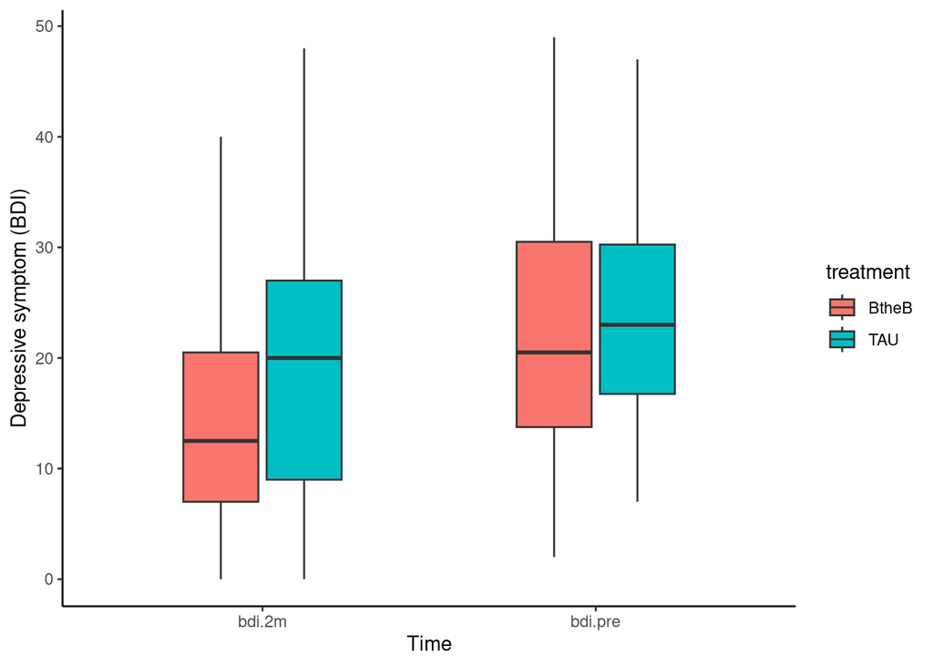

```r
ggplot(data=long_data,
       aes(x=time,y=value,fill=treatment))  +geom_boxplot(width=.5)+
  xlab("Time")+ylab("Depressive symptom (BDI)")+theme_classic()
```

- x軸のラベルの順序を変更

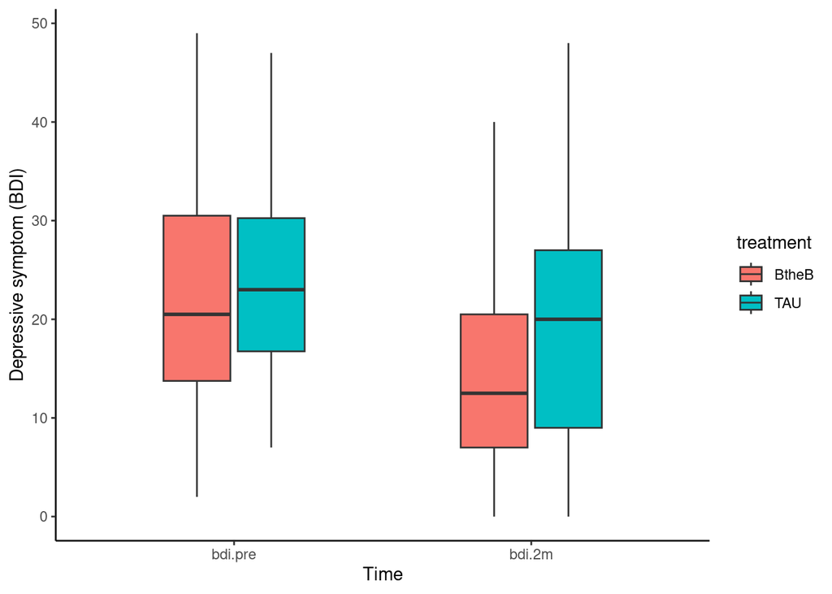

```r
ggplot(data=long_data,
       aes(x=factor(time, levels = c("bdi.pre", "bdi.2m")),y=value,fill=treatment))  +geom_boxplot(width=.5)+
  xlab("Time")+ylab("Depressive symptom (BDI)")+theme_classic()
```

- ポイントプロット
- エラーバーを重ねる
- ラインを重ねる

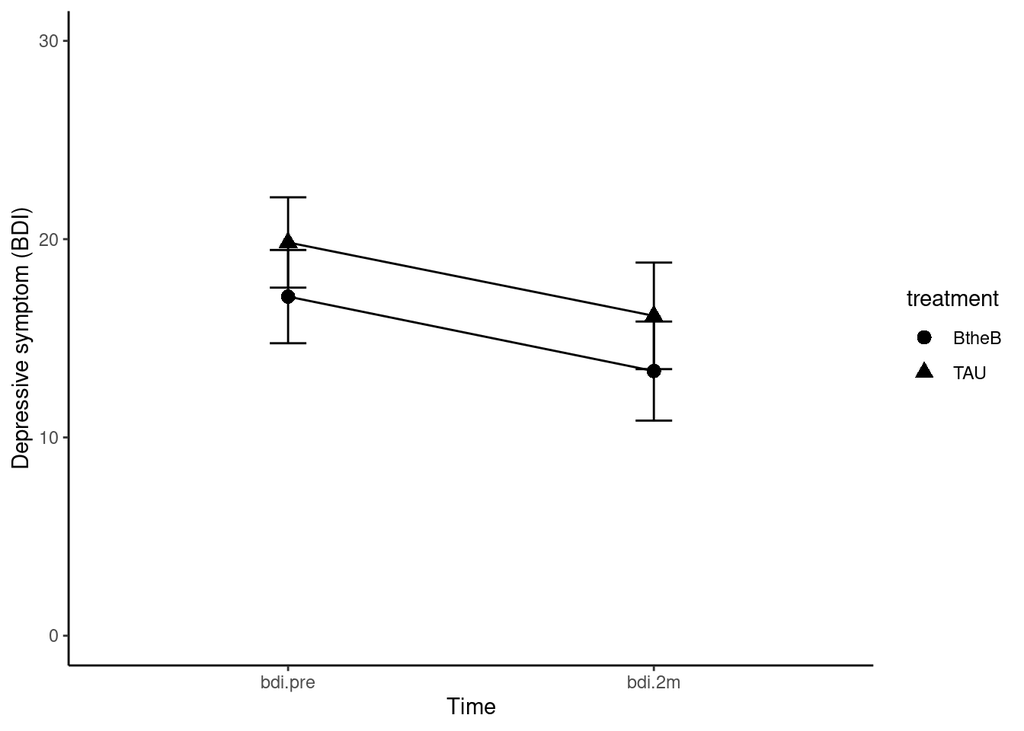

```r
ggplot(data=long_data,
       aes(x=factor(time, levels = c("bdi.pre", "bdi.2m")),
           y=value,group=treatment,na.rm=T)) +
  stat_summary(aes(shape=treatment),fun.y = mean,
               geom = "point",size=3) +
  stat_summary(fun.data = mean_cl_normal,
               geom = "errorbar",width=0.1)+
  stat_summary(fun.y = mean,
               geom = "line")+
  xlab("Time")+ylab("Depressive symptom (BDI)")+theme_classic()+
  ylim(0,30)
```

### ラインプロット: プレから8ヶ月後までの群間差

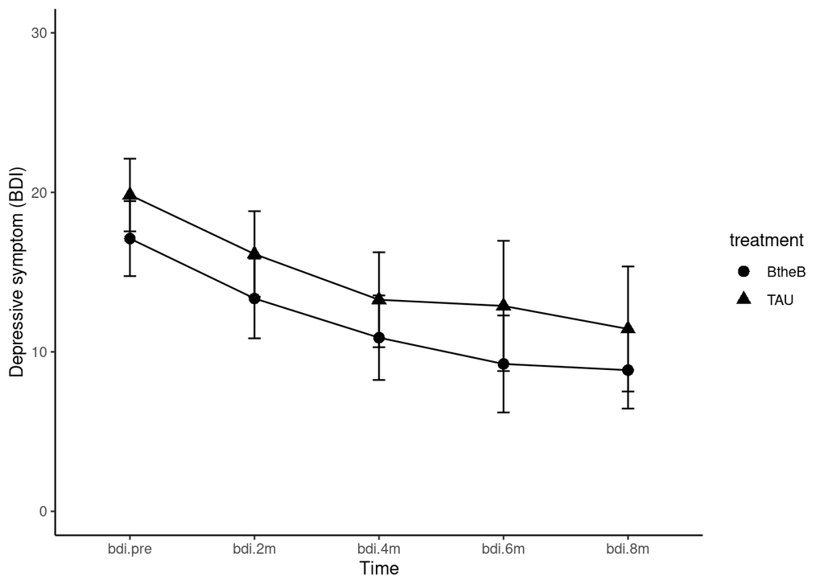

```r
long_data<-data |> select(id,treatment,starts_with("bdi")) |>
  pivot_longer(cols=starts_with("bdi"), names_to="time",values_to="value")


ggplot(data=long_data,
       aes(x=factor(time, levels = c("bdi.pre", "bdi.2m","bdi.4m", "bdi.6m", "bdi.8m")),
           y=value,group=treatment)) +
  stat_summary(aes(shape=treatment),fun.y = mean,
               geom = "point",size=3, na.rm = TRUE) +
  stat_summary(fun.data = mean_cl_normal,
               geom = "errorbar",width=0.1, na.rm = TRUE)+
  stat_summary(fun.y = mean,
               geom = "line", na.rm = TRUE)+
  xlab("Time")+ylab("Depressive symptom (BDI)")+theme_classic()+
  ylim(0,30)
```

### GUIでggplotをお手軽に: おまけ動画

- `ggplotgui` パッケージ

```r
library(ggplotgui)
ggplot_shiny(long_data)
```

### 相関行列の可視化: おまけ動画

- `ggcorrplot` パッケージ

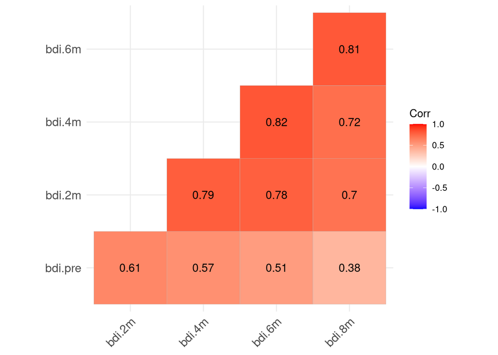

```r
library(ggcorrplot)
pmat<-data |> select(starts_with("bdi")) |> cor_pmat(use="pairwise")


data |> select(starts_with("bdi")) |> cor(use="pairwise") |>
    ggcorrplot(type = "lower",lab = TRUE,
               p.mat=pmat,insig="blank")
```

### 散布図行列: おまけ動画

- `GGally` パッケージの`ggpairs`
- データの分布や記述統計のプロットを確認

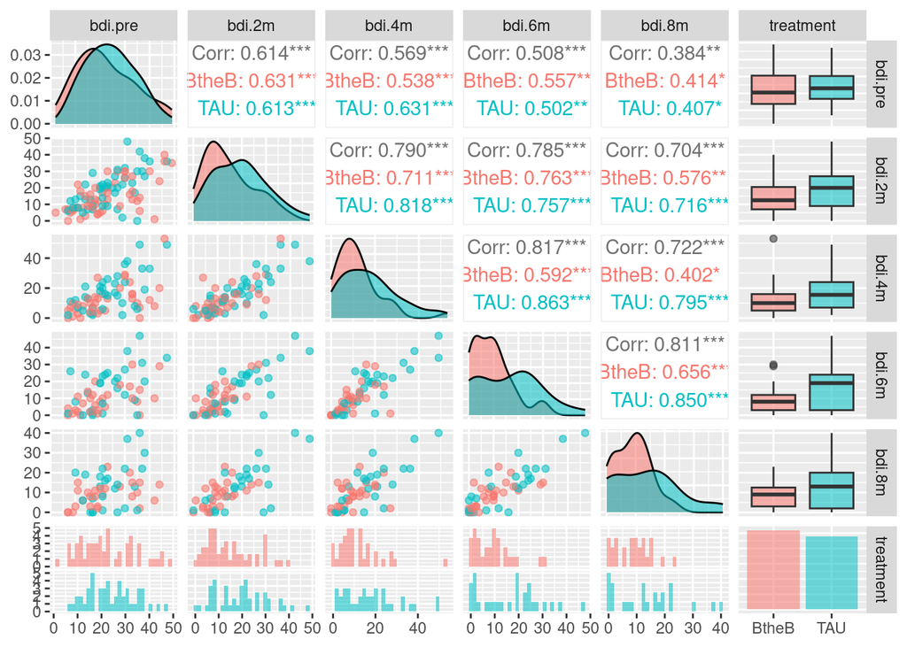

```r
library(GGally)
data |> select(starts_with("bdi"),treatment) |>
  ggpairs(ggplot2::aes(colour = treatment, alpha = 0.5))
```

### プロットの保存

- `Plots` -> `Save as Image…` jpg, png など
- `Plots` -> `Save as Image…` pdfで保存
- `Plots` -> `Copy to Clipboard...` クリップボードにコピー

### [データ可視化のggplotチートシート](https://posit.co/wp-content/uploads/2022/10/data-visualization-1.pdf)

## 5. 記述統計を求めてまとめよう

- `summary(データフレーム)` 記述統計を確認
  - 平均、中央値、最大値、最小値、4分位点

```r
data|> summary()
```

```
##        id             drug              length           treatment
##  Min.   :  1.00   Length:100         Length:100         Length:100
##  1st Qu.: 25.75   Class :character   Class :character   Class :character
##  Median : 50.50   Mode  :character   Mode  :character   Mode  :character
##  Mean   : 50.50
##  3rd Qu.: 75.25
##  Max.   :100.00
##
##     bdi.pre          bdi.2m          bdi.4m          bdi.6m
##  Min.   : 2.00   Min.   : 0.00   Min.   : 0.00   Min.   : 0.00
##  1st Qu.:15.00   1st Qu.: 8.00   1st Qu.: 6.00   1st Qu.: 3.00
##  Median :22.00   Median :15.00   Median :13.00   Median :10.00
##  Mean   :23.33   Mean   :16.92   Mean   :14.81   Mean   :12.76
##  3rd Qu.:30.25   3rd Qu.:23.00   3rd Qu.:20.00   3rd Qu.:20.00
##  Max.   :49.00   Max.   :48.00   Max.   :53.00   Max.   :47.00
##                  NA's   :3       NA's   :27      NA's   :42
##      bdi.8m
##  Min.   : 0.00
##  1st Qu.: 3.00
##  Median :10.50
##  Mean   :11.13
##  3rd Qu.:15.25
##  Max.   :40.00
##  NA's   :48
```

- `gtsummary`パッケージ
  - 簡単に綺麗な記述統計の表ができる
  - 使用変数を選択したら、`tbl_summary` であとはよしなに
  - `by = カテゴリ変数名` で群ごとの記述統計を算出
  - 群間の単変量解析のp値も算出可能

```r
library(gtsummary)
data |> select(-id) |> tbl_summary(by = treatment, missing = "no") |>
  add_n() |> add_p()|>
  modify_header(label = "**Variable**") |>
  bold_labels()
```

| **Variable** | **N** | **BtheB**, N = 52<sup>1</sup> | **TAU**, N = 48<sup>1</sup> | **p-value**<sup>2</sup> |
| --- | --- | --- | --- | --- |
| drug | 100 | 30 (58%) | 14 (29%) | 0.004 |
| length | 100 |  |  | 0.8 |
| <6m |  | 26 (50%) | 23 (48%) |  |
| >6m |  | 26 (50%) | 25 (52%) |  |
| bdi.pre | 100 | 20 (14, 30) | 23 (17, 30) | 0.3 |
| bdi.2m | 97 | 12 (7, 20) | 20 (9, 27) | 0.026 |
| bdi.4m | 73 | 10 (5, 16) | 16 (7, 24) | 0.041 |
| bdi.6m | 58 | 8 (3, 12) | 19 (3, 24) | 0.046 |
| bdi.8m | 52 | 9 (3, 12) | 13 (2, 20) | 0.2 |

<sup>1</sup> n (%); Median (IQR)  
<sup>2</sup> Pearson's Chi-squared test; Wilcoxon rank sum test

- 記述統計きれいにまとめる[gtsummaryのチートシート](https://raw.githubusercontent.com/rstudio/cheatsheets/main/gtsummary.pdf)

## 6. 関数を使って分析をしてみよう

### 2群間の平均の差（t検定)

```r
library(broom)
res<-t.test(bdi.2m~treatment,data=data)
res
```

```
##
##  Welch Two Sample t-test
##
## data:  bdi.2m by treatment
## t = -2.1941, df = 90.025, p-value = 0.0308
## alternative hypothesis: true difference in means between group BtheB and group TAU is not equal to 0
## 95 percent confidence interval:
##  -9.0606076 -0.4496488
## sample estimates:
## mean in group BtheB   mean in group TAU
##            14.71154            19.46667
```

```r
tidy(res)
```

```
## # A tibble: 1 × 10
##   estim…¹ estim…² estim…³ stati…⁴ p.value param…⁵ conf.…⁶ conf.…⁷ method alter…⁸
##     <dbl>   <dbl>   <dbl>   <dbl>   <dbl>   <dbl>   <dbl>   <dbl> <chr>  <chr>
## 1   -4.76    14.7    19.5   -2.19  0.0308    90.0   -9.06  -0.450 Welch… two.si…
## # … with abbreviated variable names ¹estimate, ²estimate1, ³estimate2,
## #   ⁴statistic, ⁵parameter, ⁶conf.low, ⁷conf.high, ⁸alternative
```

### 回帰分析

- 治療前から8ヶ月後の抑うつの変化量
- プレ、群、投薬の有無で予測

```r
data<-data|> mutate(bdi.change=bdi.8m - bdi.pre)



res<-lm(bdi.change~bdi.pre+treatment+drug,data=data)

library(lm.beta)
# 標準化回帰係数を求めるパッケージ
res2<-lm.beta(res)

summary(res2)
```

```
##
## Call:
## lm(formula = bdi.change ~ bdi.pre + treatment + drug, data = data)
##
## Residuals:
##     Min      1Q  Median      3Q     Max
## -15.678  -5.264  -1.159   4.772  20.784
##
## Coefficients:
##              Estimate Standardized Std. Error t value Pr(>|t|)
## (Intercept)    1.9554           NA     3.2595   0.600    0.551
## bdi.pre       -0.6069      -0.5552     0.1307  -4.645 2.67e-05 ***
## treatmentTAU   3.1088       0.1493     2.4998   1.244    0.220
## drugYes       -2.9566      -0.1417     2.5767  -1.147    0.257
## ---
## Signif. codes:  0 '***' 0.001 '**' 0.01 '*' 0.05 '.' 0.1 ' ' 1
##
## Residual standard error: 8.497 on 48 degrees of freedom
##   (48 observations deleted due to missingness)
## Multiple R-squared:  0.3842, Adjusted R-squared:  0.3457
## F-statistic: 9.982 on 3 and 48 DF,  p-value: 3.173e-05
```

```r
tidy(res2)
```

```
## # A tibble: 4 × 6
##   term         estimate std_estimate std.error statistic   p.value
##   <chr>           <dbl>        <dbl>     <dbl>     <dbl>     <dbl>
## 1 (Intercept)     1.96        NA         3.26      0.600 0.551
## 2 bdi.pre        -0.607       -0.555     0.131    -4.64  0.0000267
## 3 treatmentTAU    3.11         0.149     2.50      1.24  0.220
## 4 drugYes        -2.96        -0.142     2.58     -1.15  0.257
```

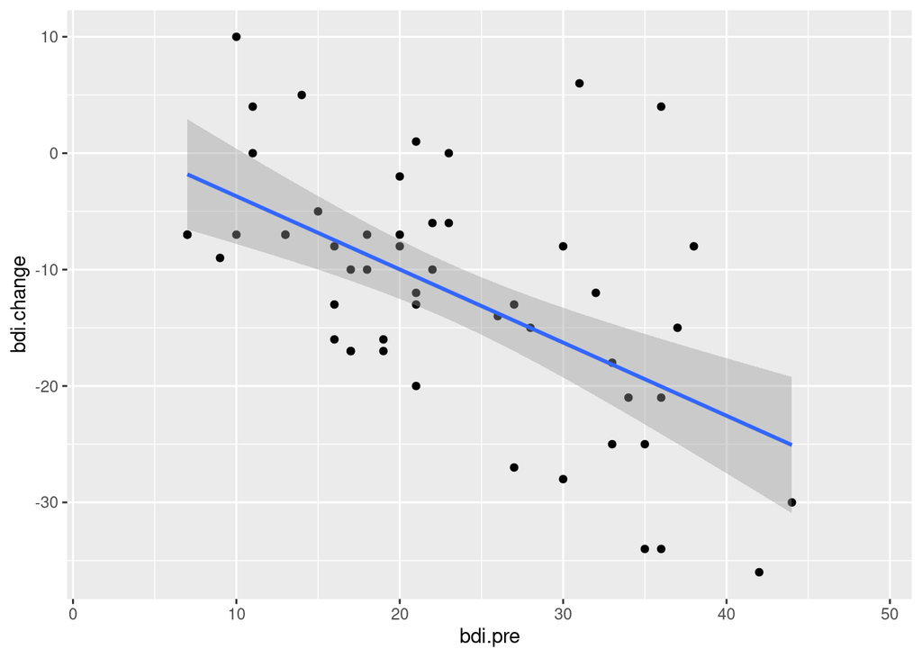

```r
ggplot(data=data,aes(x=bdi.pre,y=bdi.change))+geom_point()+geom_smooth(method="lm")
```